# Homework 9 - Naiara Alonso Montes

## Ex 1

### What is being calculated, how, which graphs are more interesting, and why? Which parameters describe the graphs the best in your opinion?

In the sample code, there are calculations about graph properties:

- **Basic properties**, number of nodes, number of edge, density...
- **PageRank**, node importance based on the conectivity (browser results worked like that at the very begining, the most cross-referenced webpage was on the top of the search)
- **Degree distribution**, number of nodes with X edges
- **Community detection**, identify groups of node that are more densely connected.

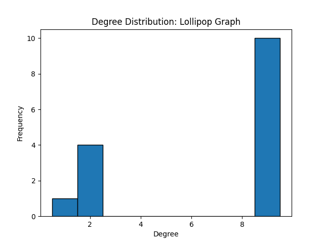

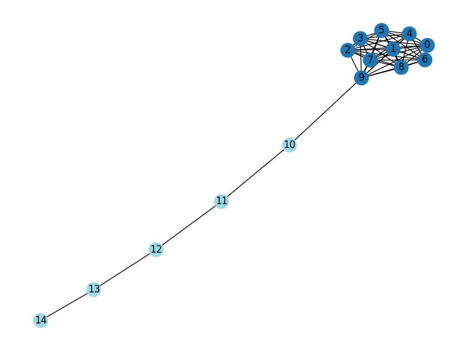

Community example (Lollipop Graph dataset)

By parameter I guess it refers to a numeric value and not a visual representation. In my opinion, there are 3 parameters that describe a graph, that are the conectivity boolean (true/false), number of nodes and average degree.

With this parameters, without knowing the visual represenentation of the graph, you can have an idea on how does it looks like. Conectivity is pretty obvious measure, even though it does not specify if there are more than 2 components. For the number of nodes and average degree, there is a relation. For example, a low nomber of nodes and a high value of average degree indicates that the graph is strongly connected in some point.

### Add some characterization model - which? What does it add?

I added the "closeness centrality" which measures how close a node is to all other nodes in the graph, based on the shortest path. A node with high closeness centrality can reach all other nodes faster than others. It helps identify nodes that can quickly spread information across the network.

## Ex 2

### Study one of the chosen random graph generation models - describe what it does, why, and how the model parameters affect it. Use the simulator to generate (many) data sets using that model; and analyze them.

I decided to use the Erdős-Rényi Graph. Here are the results, first for fixed nodes and probability change, and secondly for changing nodes and fixed probability:

Nodes = 30

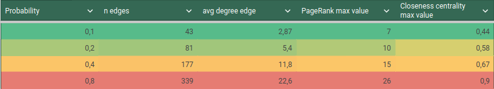

As seen in the table, the increase ratio of values is done according to the probability, as the colors for every line are "almost" uniform.

Now, fixed probability = 0.2

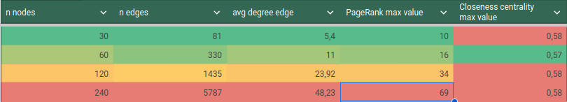

## Ex 3

### Create an example graph data yourself

With the help of ChatGPT, I creates a graph that represents people, their interest, location and age.

Here is the dataset:

| Person | Age | Interests | Location |
| --- | --- | --- | --- |
| 1 | 42 | Art, Gaming | New York |
| 2 | 34 | Cooking, Gaming | Berlin |
| 3 | 37 | Gaming, Reading | Tokyo |
| 4 | 31 | Cooking, Sports | Paris |
| 5 | 26 | Art, Music | Tokyo |
| 6 | 34 | Cooking, Traveling | Tokyo |
| 7 | 27 | Reading, Music | Sydney |
| 8 | 22 | Art, Traveling | Paris |
| 9 | 48 | Cooking, Music | Paris |
| 10 | 45 | Reading, Cooking | Sydney |

The edge and weight of the edge is computed for every pair of people as:

- Same city 1 point
- Number of common iterests * 0.5 points
- If less than 5 years difference 1 point, else if less than 10 years difference 0.5 point.

The maximum points/weight is 3.

The resulting graph is the following:

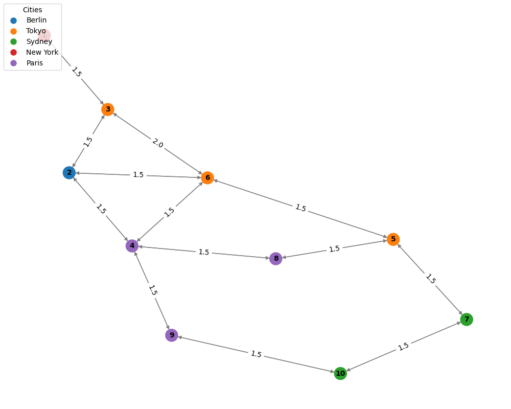

.

The color of the nodes represent the city. The edges are double-directed as the weight is the same in both directions.

This is the results for the graph caracterization:

| Number of nodes | Number of edges | Average degree | Density | Average clustering coefficient | Is connected | Number of connected components |
| --- | --- | --- | --- | --- | --- | --- |
| 10 | 26 | 5.20 | 0.2889 | 0.15 | True | 1 |

## Ex 4

### Greedy analysis

A greedy algorithm can be defined as a really optimistig algorithm, due to its assumption that the next optimal step will lead to the optimal solution. It does not consider the whole overview of a problem and it is easy to make it fail. Besides, once the decision is made, it cannot be revesersed.

On easy example is going through a maze. A greedy algorithm can go any direction, but once a step is made i cannot be undo. If the step taken leads to no solution, it will stop and say that there is no solution, even if it was possible to solve the problem. It is true that greedy algorithms FIND an optimal solution but not always.

I create a simple example of searching the most weighted path from a node. The graph is a tree. I used for the optimal solution DFS. I represented both outcomes in a GIF (sorry for the infinite loop). The number that is not really well seen is 1000.

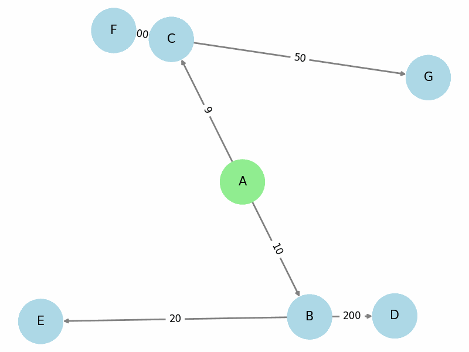

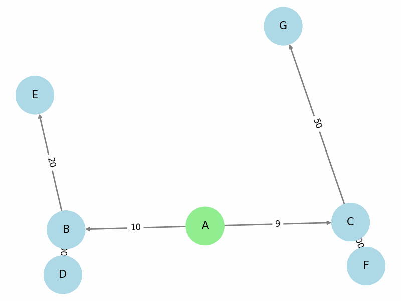

### Greedy performing poorly

I self created a dataset for the set cover problem:

| Set | Weight |
| --- | --- |
| {1, 2, 3, 4, 5, 6, 7, 8, 9, 10} | 10 |
| {1, 2, 3, 4} | 1 |
| {5, 6, 7} | 1 |
| {8, 9, 10} | 1 |

The greedy algorithm will choose the set that covers the most of the universe, independently on the cost. Here are the results:

```
Greedy Solution Total Weight: 10.00
Greedy Algorithm Time: 0.0000 seconds
Greedy Solution Number of Sets: 1
Greedy Solution Sets and Weights: [{'elements': [1, 2, 3, 4, 5, 6, 7, 8, 9, 10], 'weight': 10, 'index': 0}]

=============

Optimal Solution Total Weight: 3.00
Optimal Algorithm Time: 0.0049 seconds
Optimal Solution Number of Sets: 3
Optimal Solution Sets and Weights: [{'elements': [1, 2, 3, 4], 'weight': 1, 'index': 1}, {'elements': [5, 6, 7], 'weight': 1, 'index': 2}, {'elements': [8, 9, 10], 'weight': 1, 'index': 3}]
```

The optimal solution takes more time, but it is *optimal*. The greedy algorithm takes the first set, and, as it covers the whole universe, it stops and returns, whitout going through the rest of the subsets.

## Ex 5

### Random sets

| Example | Universe Size | Number of Subsets | Greedy Solution Total Weight | Greedy Algorithm Time (seconds) | Optimal Solution Total Weight | Optimal Algorithm Time (seconds) |
| --- | --- | --- | --- | --- | --- | --- |
| 1 | 10 | 50 | 5.00 | 0.0000 | 2.00 | 0.0054 |
| 2 | 20 | 50 | 5.00 | 0.0001 | 1.00 | 0.0061 |
| 3 | 50 | 50 | 8.00 | 0.0001 | 4.00 | 0.0115 |
| 4 | 100 | 50 | 11.00 | 0.0002 | 4.00 | 0.0349 |
| 5 | 200 | 50 | 15.00 | 0.0004 | N/A | N/A |
| 6 | 500 | 50 | 12.00 | 0.0007 | N/A | N/A |
| 7 | 1000 | 50 | 10.00 | 0.0013 | N/A | N/A |

The greedy algorithm will work for all amount of data, we assume that it does not return always the best solution, but it works.

The optimal solution will find the best solution, but for a large universe, it might not work, as it is this case.

```python
!jupyter nbconvert --to html HW9.ipynb
```